# ETC5521 Worksheet Week 4

Assessing significance of patterns

Author

Prof. Di Cook

## Packages and preparation

This worksheet requires R version 4.5.0 or later (so that `penguins` is available without any extra package) plus three packages. Install them once from CRAN if you have not already done so:

```r
install.packages(c("tidyverse", "nullabor", "MASS"))
```

Then load them at the start of your session:

```r
library(tidyverse)   # ggplot2, dplyr, and friends
library(nullabor)    # lineup(), rorschach(), pvisual(), null_permute(), null_lm()
library(MASS)        # mvrnorm() — multivariate normal simulation (Exercise 3 only)
```

| Package | Role in this worksheet | Version used |
| --- | --- | --- |
| **tidyverse** [@Wickham2019] | Data wrangling (`dplyr`, `tidyr`) and plotting (`ggplot2`) | ≥ 2.0 |
| **nullabor** [@Buja2009] | Lineup and Rorschach protocols, null-generating functions, `pvisual()` | ≥ 0.3.10 |
| **MASS** [@Venables2002] | `mvrnorm()` for bivariate normal simulation in Exercise 3 | ≥ 7.3 |

The `penguins` dataset is part of the **datasets** package that ships with base R (≥ 4.5.0) [@Kaye2025], so no additional install is needed for the data.

> *“The most important maxim for data analysis … is that it is better to look at the data than to stare at the output of a statistical test.”* — John W. Tukey

A **lineup** is a way of making this idea rigorous. You hide the real data among a set of plots generated under the assumption that nothing interesting is happening (the **null hypothesis**), then ask an observer — you, your classmates, or anyone — to identify which plot is real. If the real data is easy to find, that is evidence something interesting is happening. If it blends in with the rest, the data are consistent with the null hypothesis.

Before we put real data in a lineup, we need to know what “nothing interesting” looks like. That is what the **Rorschach** protocol is for: it shows a set of plots that are *all* generated under the null, with no real data at all. This calibrates your eye.

This worksheet introduces both protocols using the `penguins` dataset, which has been part of base R since version 4.5.0. No extra packages are needed to load the data.

> **R version note.** The base R `penguins` dataset uses shorter variable names than the `palmerpenguins` package version. The names used in this worksheet are: `bill_len`, `bill_dep`, `flipper_len`, and `body_mass` (without unit suffixes).

## 🎯 Learning Objectives

By the end of this worksheet you should be able to:

1. Explain the purpose of the **Rorschach protocol** and use it to calibrate your eye to natural random variation.
2. Explain the purpose of the **lineup protocol** and use it to decide whether a pattern in data is surprising.
3. Choose an appropriate **null-generating mechanism** (`null_permute`, `null_dist`, or `null_lm`) given a description of the plot and the hypothesis being tested.
4. Construct a lineup using `nullabor::lineup()` and display it with `facet_wrap()`.
5. Compute a **visual p-value** with `pvisual()` and state a conclusion.

## Setup: meet the data

```r
# The data loads automatically in R >= 4.5.0
glimpse(penguins)
```

```
Rows: 344
Columns: 8
$ species     <fct> Adelie, Adelie, Adelie, Adelie, Adelie, Adelie, Adelie, Ad…
$ island      <fct> Torgersen, Torgersen, Torgersen, Torgersen, Torgersen, Tor…
$ bill_len    <dbl> 39.1, 39.5, 40.3, NA, 36.7, 39.3, 38.9, 39.2, 34.1, 42.0, …
$ bill_dep    <dbl> 18.7, 17.4, 18.0, NA, 19.3, 20.6, 17.8, 19.6, 18.1, 20.2, …
$ flipper_len <int> 181, 186, 195, NA, 193, 190, 181, 195, 193, 190, 186, 180,…
$ body_mass   <int> 3750, 3800, 3250, NA, 3450, 3650, 3625, 4675, 3475, 4250, …
$ sex         <fct> male, female, female, NA, female, male, female, male, NA, …
$ year        <int> 2007, 2007, 2007, 2007, 2007, 2007, 2007, 2007, 2007, 2007…
```

There are three species of penguin — Adélie, Chinstrap, and Gentoo — measured on four physical variables (`bill_len`, `bill_dep`, `flipper_len`, `body_mass`) along with `sex`, `island`, and `year`.

## Exercise 1 — The Rorschach: what does nothing look like?

### Background

Before you can judge whether a pattern in your data is real, you need to know what patterns arise **by chance alone**. The Rorschach protocol generates several plots that are all pure noise — no real data anywhere. Looking at them trains your eye before you see a lineup.

The question for this exercise is: *do the three penguin species have different flipper lengths?* The plot we will use is a boxplot of `flipper_len` by `species`.

The null hypothesis is: **species labels are exchangeable** — knowing which species a penguin belongs to tells you nothing about its flipper length. We generate null data by randomly shuffling (`permuting`) the `species` column, so each penguin keeps its actual flipper length but gets a randomly assigned species label.

### The null-generating function

`null_permute("species")` generates one dataset where the species labels have been randomly shuffled. We call `rorschach()`, which repeats this shuffling `n` times to produce 20 such datasets — no real data anywhere.

**a.** In every panel, the species labels are randomly shuffled, so any difference between the three boxes is pure chance. Do the three boxes look roughly the same height in most panels, or do they vary quite a bit?

**b.** Find a panel where one species looks noticeably higher or lower than the others. Write down the panel number. Would you have been suspicious of that panel if you had seen it alone, without the other 19?

**c.** Now think about what the *real* data would have to look like to stand out from these panels. Describe in one sentence what you would need to see in the real data plot for it to be clearly distinguishable from the null panels.

**SolutionSolution**

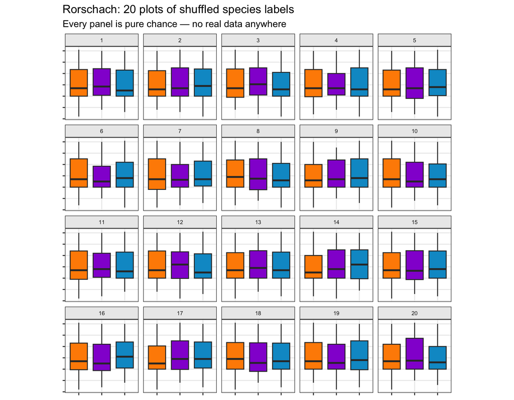

```r
set.seed(840)

# Remove rows with missing flipper_len for clean plots
penguins_flip <- penguins |>
  filter(!is.na(flipper_len), !is.na(species))

# Generate 20 null datasets — all pure chance, no real data
rorschach_data <- rorschach(
  method = null_permute("species"),
  true   = penguins_flip,
  n      = 20
)

ggplot(rorschach_data,
       aes(x      = species,
           y      = flipper_len,
           fill   = species)) +
  geom_boxplot(show.legend = FALSE, outlier.size = 0.5) +
  scale_fill_manual(
    values = c(Adelie    = "#FF8C00",
               Chinstrap = "#9400D3",
               Gentoo    = "#009ACD")
  ) +
  facet_wrap(~ .sample, ncol = 5) +
  labs(
    title    = "Rorschach: 20 plots of shuffled species labels",
    subtitle = "Every panel is pure chance — no real data anywhere",
    x        = NULL,
    y        = NULL
  ) +
  theme(
    axis.text  = element_blank(),
    strip.text   = element_text(size = 7)
  )
```

**a.** In most panels the three boxes are fairly similar in height (median and IQR), with small random differences between species. Occasionally one panel shows a larger gap than others, purely by chance. The overall impression is that random shuffling produces modest, inconsistent differences — the three boxes bob around a shared centre.

**b.** Answers will vary by seed. The point is that any individual “suspicious” panel is entirely explainable by chance — we generated it that way. Seeing one plot in isolation, without the Rorschach context, would give a distorted impression of how unusual that pattern is.

**c.** To stand out clearly, the real data would need to show one or more species with a median noticeably *outside* the range of medians seen in the null panels — for instance, one box sitting substantially higher than both others, in a way that no null panel replicates. Differences that appear in some null panels are not convincing evidence; the real data needs to show something that the null panels never (or very rarely) produce.

## Exercise 2 — The lineup: do species differ in flipper length?

### Background

Now we embed the **real** penguin data among 19 null panels generated by the same permutation mechanism. This is the lineup protocol.

**a.** Look carefully at all 20 panels. Write down which panel you think contains the real data and the specific feature that identified it.

**b.** The null hypothesis being tested is: *species labels are exchangeable — flipper length does not differ between species.* What does it mean for the real panel to stand out clearly from the null panels, in terms of this hypothesis?

**c.** Decrypt the lineup to reveal the true position. Were you correct?

**d.** Suppose this lineup was shown to 16 students and 14 of them correctly identified the real panel. Compute the visual p-value and state your conclusion. The lineup has $m = 20$ panels.

**e.** Describe what the p-value means in plain language, without using the word “probability”. Use the lineup panels to explain your answer.

**SolutionSolution**

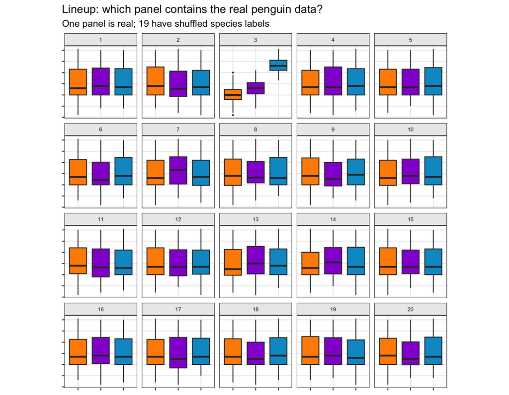

```r
set.seed(1035)

lineup_flip <- lineup(
  method = null_permute("species"),
  true   = penguins_flip,
  n      = 20
)

ggplot(lineup_flip,
       aes(x    = species,
           y    = flipper_len,
           fill = species)) +
  geom_boxplot(show.legend = FALSE, outlier.size = 0.5) +
  scale_fill_manual(
    values = c(Adelie    = "#FF8C00",
               Chinstrap = "#9400D3",
               Gentoo    = "#009ACD")
  ) +
  facet_wrap(~ .sample, ncol = 5) +
  labs(
    title    = "Lineup: which panel contains the real penguin data?",
    subtitle = "One panel is real; 19 have shuffled species labels",
    x        = NULL,
    y        = NULL
  ) +
  theme(
    axis.text = element_blank(),
    strip.text  = element_text(size = 7)
  )
```

```r
attr(lineup_flip, "pos")
```

```
[1] 3
```

```r
pvisual(x = 14, K = 16, m = 20)
```

```
      x simulated binom
[1,] 14         0     0
```

**a.** The real data panel should have Gentoo penguins with a noticeably higher median flipper length than Adélie and Chinstrap, and all three species clearly separated — a pattern not reproduced in any null panel, where the three medians sit at similar heights because species labels have been shuffled.

**b.** If the real panel clearly stands out, it means the species-level differences in flipper length are larger and more consistent than what chance shuffling of species labels would produce. In other words, the pattern is *surprising* under the null hypothesis — it would rarely arise if species truly made no difference.

**c.**

```r
attr(lineup_flip, "pos")
```

```
[1] 3
```

**d.**

```r
pvisual(x = 14, K = 16, m = 20)
```

```
      x simulated binom
[1,] 14         0     0
```

With 14 of 16 students identifying the correct panel, the simulated p-value is very small (well below 0.05). We reject the null hypothesis and conclude there is strong visual evidence that flipper lengths differ between species.

**e.** The p-value tells us how often students would pick the *same* panel by pure guessing, if the real panel were indistinguishable from the nulls. If guessing randomly, each student has a 1-in-20 chance of picking any particular panel. Getting 14 out of 16 students to all point to the same panel by chance alone would be extraordinary — the lineup shows us exactly why, because the real panel looks nothing like the 19 null panels that everyone can also see.

## Exercise 3 — Is bill length and depth jointly normal for Adélie penguins?

### Background

When we plot two continuous variables against each other in a scatter plot, we are often implicitly asking whether their joint distribution follows a particular shape. A **bivariate normal distribution** is the two-dimensional generalisation of the familiar bell curve: it produces elliptically shaped scatter plots with no outliers or curved structure.

The code below will make a plot of bill length (`bill_len`) against bill depth (`bill_dep`) for Adélie penguins.

```r
adelie <- penguins |>
  filter(species == "Adelie",
         !is.na(bill_len), !is.na(bill_dep))

ggplot(adelie, aes(x = bill_len, y = bill_dep)) +
  geom_point(colour = "#FF8C00", alpha = 0.6, size = 2) +
  labs(
    title = "Adélie penguins: bill length vs bill depth",
    x     = "Bill length (mm)",
    y     = "Bill depth (mm)"
  )
```

### Choosing the null-generating mechanism

To test whether this scatter plot is consistent with a bivariate normal distribution, we need to generate null datasets that *are* bivariate normal with the same means, variances, and correlation as the observed data.

The `null_dist()` function in nullabor can generate data from a named distribution, but it works on one variable at a time. For a bivariate normal we use `null_lm()` — not because we are fitting a regression, but because regressing `bill_dep` on `bill_len` and rotating the residuals generates null scatter plots that preserve the linear relationship’s strength while removing any non-normal structure.

Alternatively, and more directly, we can write our own null-generating function that simulates from a bivariate normal with parameters estimated from the data.

```r
library(MASS)  # for mvrnorm()

adelie <- penguins |>
  filter(species == "Adelie",
         !is.na(bill_len), !is.na(bill_dep))

# Estimate bivariate normal parameters from the data
bvn_params <- list(
  mu    = c(mean(adelie$bill_len), mean(adelie$bill_dep)),
  Sigma = cov(cbind(adelie$bill_len, adelie$bill_dep))
)

# Null-generating function: simulate one bivariate normal dataset
null_bvn <- function(data) {
  n    <- nrow(data)
  sims <- mvrnorm(n, mu = bvn_params$mu, Sigma = bvn_params$Sigma)
  data.frame(bill_len = sims[, 1],
             bill_dep = sims[, 2])
}
```

**a.** Why is it important that the simulated null data have the *same* means, variances, and correlation as the observed data? What would go wrong if we simulated from a standard bivariate normal with mean 0 and variance 1?

**b.** The lineup below uses `null_bvn` as the null-generating function. Before looking at the panels, predict: if the real data are *consistent* with a bivariate normal, how hard should it be to find the real panel?

**c.** Write down which panel you think is the real data and what feature (if any) made it stand out. If you genuinely cannot tell, write that down too — that is also a valid and informative result.

**d.** Decrypt.

**e.** Suppose 6 out of 18 students found the real panel. Compute the visual p-value. What does the result tell you about whether the bivariate normal is an adequate model for Adélie bill measurements?

**f.** The null here is `null_bvn` — simulation from a bivariate normal. Contrast this with Exercise 2, where the null was `null_permute("species")`. In your own words, what is the key difference in what these two null mechanisms *destroy* or *preserve*?

**SolutionSolution**

**a.** If we simulated from a standard bivariate normal (mean 0, variance 1), the null scatter plots would be centred at the origin and have a much smaller scale than the real data, which has bill lengths around 38–46 mm and bill depths around 15–21 mm. The real panel would immediately stand out because of its location and scale, not because of its shape. By matching the parameters to the data, we ensure that any visual difference between the real panel and the null panels must be due to *shape* (non-normality) rather than location or scale.

**b.** If the bivariate normal is a good model, the real data panel should look like any of the null panels — roughly elliptical scatter with similar density and no obvious outliers or curvature. It should be hard to find. If it is easy to find, that is evidence of non-normality.

**c–d.**

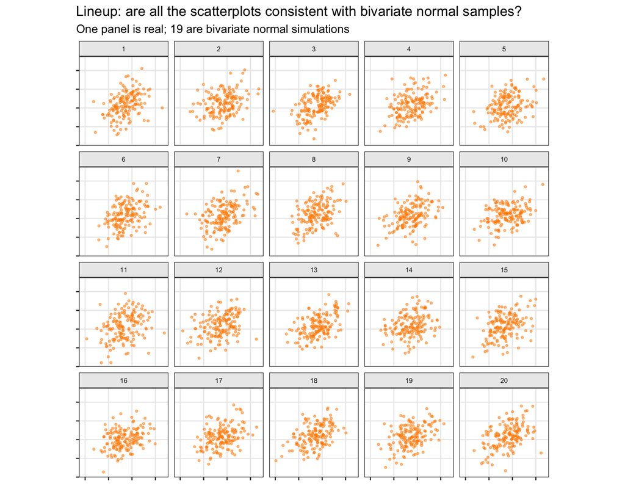

```r
set.seed(904)

lineup_bvn <- lineup(
  method = null_bvn,
  true   = adelie[, c("bill_len", "bill_dep")],
  n      = 20
)

ggplot(lineup_bvn,
       aes(x = bill_len, y = bill_dep)) +
  geom_point(colour = "#FF8C00", alpha = 0.5, size = 0.8) +
  facet_wrap(~ .sample, ncol = 5) +
  labs(
    title    = "Lineup: are all the scatterplots consistent with bivariate normal samples?",
    subtitle = "One panel is real; 19 are bivariate normal simulations",
    x        = NULL,
    y        = NULL
  ) +
  theme(strip.text = element_text(size = 7),
        axis.text  = element_blank())
```

If you can use the `decrypt` line it is better than this approach.

```r
attr(lineup_bvn, "pos")
```

```
[1] 4
```

Adélie bill measurements are generally quite well-described by a bivariate normal, so the real panel may be genuinely hard to identify. Students who cannot find it are learning something useful: the data are consistent with the null model.

**e.**

```r
pvisual(x = 6, K = 18, m = 20)
```

```
     x simulated        binom
[1,] 6     9e-04 0.0001719662
```

**f.** `null_permute("species")` shuffles a column of labels, destroying the relationship between `species` and `flipper_len` while keeping all the actual values. `null_bvn` generates entirely new data from a parametric model — it does not use the original observations at all. The permutation null asks “is this group difference real?” The simulation null asks “does this shape of scatter match this distributional model?” One tests a relationship between variables; the other tests a distributional assumption.

## Exercise 4 — Is there a linear relationship between body mass and flipper length for Gentoo penguins?

### Background

A scatter plot of two continuous variables with a smooth line through it is implicitly asking: *is there a linear trend, or is the relationship flat?* The null hypothesis is that there is no linear relationship — any apparent slope is just random variation.

```r
gentoo <- penguins |>
  filter(species == "Gentoo",
         !is.na(body_mass), !is.na(flipper_len))

ggplot(gentoo,
       aes(x = flipper_len, y = body_mass)) +
  geom_point(colour = "#009ACD", alpha = 0.6, size = 2) +
  geom_smooth(method = "lm", se = TRUE,
              colour = "#009ACD", fill = "#009ACD", alpha = 0.2) +
  labs(
    title = "Gentoo penguins: flipper length vs body mass",
    x     = "Flipper length (mm)",
    y     = "Body mass (g)"
  )
```

[output not shown]

### Choosing the null

For this question the null-generating mechanism is:

```r
null_lm(body_mass ~ flipper_len, method = "rotate")
```

**b.** Why is `null_permute("flipper_len")` *not* a good null for this question, even though it would also destroy the linear relationship?

*Hint: think about what permuting `flipper_len` does to its marginal distribution and whether values of 180 mm and 230 mm are equally plausible for the same penguin.*

Now generate the lineup.

**c.** Look at the 20 panels. Write down which panel you think is real and the visual feature that led you there.

**d.** Decrypt.

**e.** Suppose 15 out of 17 students found the real panel. Compute the visual p-value and state your conclusion.

**f.** The lineup includes a `geom_smooth(method = "lm")` line in every panel, including the null panels. Explain why this is useful rather than misleading. What does the slope of the line in the null panels tell you?

**g.** Review all three lineups in this worksheet and complete the table below:

| Exercise | Question | Null mechanism | What the null destroys |
| --- | --- | --- | --- |
| 2 | Do species differ in flipper length? | `null_permute("species")` |  |
| 3 | Are bill dims jointly normal for Adélie? | Custom `null_bvn()` |  |
| 4 | Is there a linear relationship (Gentoo)? | `null_lm(..., "rotate")` |  |

**SolutionSolution**

**a.** The relationship looks clearly positive and roughly linear — penguins with longer flippers also tend to have greater body mass. The scatter is fairly tight around the line with no obvious curvature. There may be a slight fan shape (more spread at higher flipper lengths) but no dramatic outliers.

**c–d.**

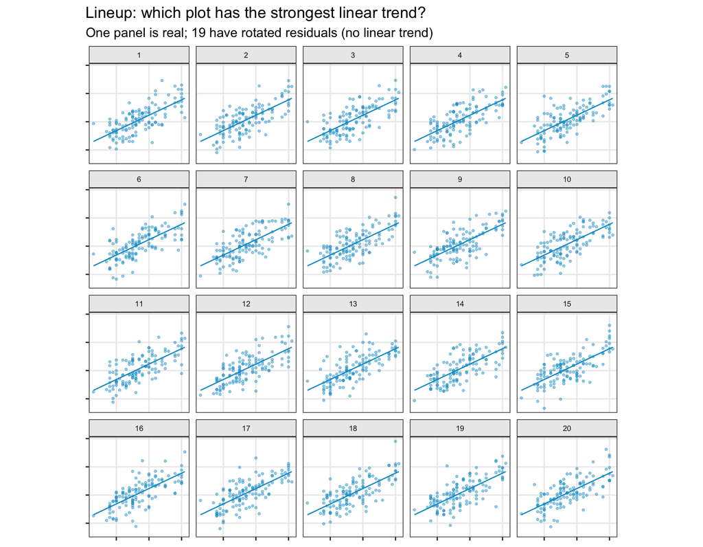

```r
gentoo <- penguins |>
  filter(species == "Gentoo",
         !is.na(body_mass), !is.na(flipper_len))

set.seed(1145)

lineup_lm <- lineup(
  method = null_lm(body_mass ~ flipper_len, method = "rotate"),
  true   = gentoo[, c("flipper_len", "body_mass")],
  n      = 20
)

ggplot(lineup_lm,
       aes(x = flipper_len, y = body_mass)) +
  geom_point(colour = "#009ACD", alpha = 0.4, size = 0.7) +
  geom_smooth(method = "lm", se = FALSE,
              colour  = "#009ACD",
              linewidth = 0.5) +
  facet_wrap(~ .sample, ncol = 5) +
  labs(
    title    = "Lineup: which plot has the strongest linear trend?",
    subtitle = "One panel is real; 19 have rotated residuals (no linear trend)",
    x        = NULL,
    y        = NULL
  ) +
  theme(strip.text = element_text(size = 7),
        axis.text  = element_blank())
```

Use the `decrypt` line, if possible.

```r
attr(lineup_lm, "pos")
```

```
[1] 13
```

**e.**

```r
pvisual(x = 15, K = 17, m = 20)
```

```
      x simulated binom
[1,] 15         0     0
```

**g.**

[output not shown]

## Summary

| Protocol | What it is | When to use it |
| --- | --- | --- |
| **Rorschach** | All panels are null — no real data | Before a lineup, to calibrate your eye to what chance looks like |
| **Lineup** | One real panel hidden among null panels | To test whether a pattern in your data is surprising |

[output not shown]

**The three steps of a lineup test:**

1. **Decide what you want to test** — state the null hypothesis in plain language.
2. **Choose a null-generating mechanism** that matches the null hypothesis.
3. **Show the lineup to observers**, record how many find the real panel, and compute `pvisual(x, K, m)`.

## References

### R packages

Wickham H, Averick M, Bryan J, Chang W, McGowan LD, François R, Grolemund G, Hayes A, Henry L, Hester J, Kuhn M, Pedersen TL, Miller E, Bache SM, Müller K, Ooms J, Robinson D, Seidel DP, Spinu V, Takahashi K, Vaughan D, Wilke C, Woo K, Yutani H (2019). “Welcome to the tidyverse.” *Journal of Open Source Software*, **4**(43), 1686. https://doi.org/10.21105/joss.01686

Buja A, Cook D, Hofmann H, Lawrence M, Lee E, Swayne DF, Wickham H (2009). “Statistical inference for exploratory data analysis and model diagnostics.” *Philosophical Transactions of the Royal Society A*, **367**(1906), 4361–4383. https://doi.org/10.1098/rsta.2009.0120

Cook D, Wickham H, Roy Chowdhury N, Hofmann H, Thulin M (2024). *nullabor: Tools for Graphical Inference*. R package version 0.3.15. https://dicook.github.io/nullabor/

Venables WN, Ripley BD (2002). *Modern Applied Statistics with S*, 4th ed. Springer, New York. ISBN 0-387-95457-0. https://www.stats.ox.ac.uk/pub/MASS4/

### Data

Kaye E, Turner H, Gorman KB, Horst AM, Presmanes Hill A (2025). “Preparing the Palmer Penguins data for the datasets package in R.” Zenodo. https://doi.org/10.5281/zenodo.14902740

Horst AM, Presmanes Hill A, Gorman KB (2022). “Palmer Archipelago penguins data in the palmerpenguins R package — an alternative to Anderson’s irises.” *The R Journal*, **14**(1), 244–254. https://doi.org/10.32614/RJ-2022-020

Gorman KB, Williams TD, Fraser WR (2014). “Ecological sexual dimorphism and environmental variability within a community of Antarctic penguins (genus *Pygoscelis*).” *PLOS ONE*, **9**(3), e90081. https://doi.org/10.1371/journal.pone.0090081

### Visual inference methodology

Wickham H, Cook D, Hofmann H, Buja A (2010). “Graphical inference for infovis.” *IEEE Transactions on Visualization and Computer Graphics*, **16**(6), 973–979. https://doi.org/10.1109/TVCG.2010.161

Majumder M, Hofmann H, Cook D (2013). “Validation of visual statistical inference, applied to linear models.” *Journal of the American Statistical Association*, **108**(503), 942–956. https://doi.org/10.1080/01621459.2013.808157

Hofmann H, Follett L, Majumder M, Cook D (2012). “Graphical tests for power comparison of competing designs.” *IEEE Transactions on Visualization and Computer Graphics*, **18**(12), 2441–2448. https://doi.org/10.1109/TVCG.2012.230

## Licence

This worksheet is released under a [Creative Commons Attribution-ShareAlike 4.0 International (CC BY-SA 4.0)](https://creativecommons.org/licenses/by-sa/4.0/) licence.

CC BY-SA 4.0

You are free to **share** (copy and redistribute in any medium or format) and **adapt** (remix, transform, and build upon) this material for any purpose, even commercially, provided you:

- give **appropriate credit** and a link to the licence,
- **indicate if changes were made**, and
- distribute your contributions under the **same licence** as the original.